# Cardio Good Fitness

## Objective:

Explore the dataset and practice extracting basic observations about the data.

1. Come up with a customer profile (characteristics of a customer) of the different products
2. Perform uni-variate and multi-variate analyses
3. Generate a set of insights and recommendations that will help the company in targeting new customers

## Key Questions:

1. What is the differences between customers of each product.

## Data:

The data is for customers of the treadmill product(s) of a retail store called Cardio Good Fitness. It contains the following variables:

1. Product - the model no. of the treadmill
2. Age - in no of years, of the customer
3. Gender - of the customer
4. Education - in no. of years, of the customer
5. Marital Status - of the customer
6. Usage - Avg. # times the customer wants to use the treadmill every week
7. Fitness - Self rated fitness score of the customer (5 - very fit, 1 - very unfit)
8. Income - of the customer
9. Miles- expected to run

### Importing the dataset

```python
import warnings
warnings.filterwarnings('ignore') #never print matching warnings
```

```python
# Importing the necessary libraries
import numpy as np
import pandas as pd
import matplotlib.pyplot as plt
import seaborn as sns
%matplotlib inline
```

```python
# Reading the dataset
data = pd.read_csv('CardioGoodFitness.csv')
```

```python
# copying data to another varaible to avoid any changes to original data
cardio = data.copy()
```

### Understanding the structure of the dataset

```python
# Visualizing 3 first rows of data
cardio.head(3)
```

|  | Product | Age | Gender | Education | MaritalStatus | Usage | Fitness | Income | Miles |
| --- | --- | --- | --- | --- | --- | --- | --- | --- | --- |
| 0 | TM195 | 18 | Male | 14 | Single | 3 | 4 | 29562 | 112 |
| 1 | TM195 | 19 | Male | 15 | Single | 2 | 3 | 31836 | 75 |
| 2 | TM195 | 19 | Female | 14 | Partnered | 4 | 3 | 30699 | 66 |

```python
# Visualizing 3 last rows of data
cardio.tail(3)
```

|  | Product | Age | Gender | Education | MaritalStatus | Usage | Fitness | Income | Miles |
| --- | --- | --- | --- | --- | --- | --- | --- | --- | --- |
| 177 | TM798 | 45 | Male | 16 | Single | 5 | 5 | 90886 | 160 |
| 178 | TM798 | 47 | Male | 18 | Partnered | 4 | 5 | 104581 | 120 |
| 179 | TM798 | 48 | Male | 18 | Partnered | 4 | 5 | 95508 | 180 |

**Observations**

- Product contains the model number of the treadmill
- Usage contain the avarege number of times the customer wants to use the treadmill every week
- Fitness its a self rated fitness score of the customer (5 - very fit, 1 - very unfit)
- Miles contain the expected miles to run per week
- The variables: Product, Gender and, MaritalStatus are categorical variable

```python
# shape of the dataset
cardio.shape
```

```
(180, 9)
```

- The dataset has 180 rows and 9 columns.

```python
# dataframe Cardio informations
cardio.info()
```

```
<class 'pandas.core.frame.DataFrame'>
RangeIndex: 180 entries, 0 to 179
Data columns (total 9 columns):
 #   Column         Non-Null Count  Dtype
---  ------         --------------  -----
 0   Product        180 non-null    object
 1   Age            180 non-null    int64
 2   Gender         180 non-null    object
 3   Education      180 non-null    int64
 4   MaritalStatus  180 non-null    object
 5   Usage          180 non-null    int64
 6   Fitness        180 non-null    int64
 7   Income         180 non-null    int64
 8   Miles          180 non-null    int64
dtypes: int64(6), object(3)
memory usage: 12.8+ KB
```

**Observations**

- All column have 180 observations non-null which indicat that there are no missing values in it *(treatment of missing values is not necessary)*.
- Product, Gender, and MaritalStatus should be categorical varaibles .

```python
# Double checking missing values, once using info were possible to see that there is no missing values
cardio.isna().sum()
```

```
Product          0
Age              0
Gender           0
Education        0
MaritalStatus    0
Usage            0
Fitness          0
Income           0
Miles            0
dtype: int64
```

### Data Preprocessing

```python
# converting categorical columns to categorical type
cardio['Product'] = cardio.Product.astype('category')
cardio['Gender'] = cardio.Gender.astype('category')
cardio['MaritalStatus'] = cardio.MaritalStatus.astype('category')
```

```python
cardio.info()
```

```
<class 'pandas.core.frame.DataFrame'>
RangeIndex: 180 entries, 0 to 179
Data columns (total 9 columns):
 #   Column         Non-Null Count  Dtype
---  ------         --------------  -----
 0   Product        180 non-null    category
 1   Age            180 non-null    int64
 2   Gender         180 non-null    category
 3   Education      180 non-null    int64
 4   MaritalStatus  180 non-null    category
 5   Usage          180 non-null    int64
 6   Fitness        180 non-null    int64
 7   Income         180 non-null    int64
 8   Miles          180 non-null    int64
dtypes: category(3), int64(6)
memory usage: 9.4 KB
```

```python
# checking descriptive statistics
# include all means even the ones that is not numerical like categorical
cardio.describe(include='all')
```

|  | Product | Age | Gender | Education | MaritalStatus | Usage | Fitness | Income | Miles |
| --- | --- | --- | --- | --- | --- | --- | --- | --- | --- |
| count | 180 | 180.000000 | 180 | 180.000000 | 180 | 180.000000 | 180.000000 | 180.000000 | 180.000000 |
| unique | 3 | NaN | 2 | NaN | 2 | NaN | NaN | NaN | NaN |
| top | TM195 | NaN | Male | NaN | Partnered | NaN | NaN | NaN | NaN |
| freq | 80 | NaN | 104 | NaN | 107 | NaN | NaN | NaN | NaN |
| mean | NaN | 28.788889 | NaN | 15.572222 | NaN | 3.455556 | 3.311111 | 53719.577778 | 103.194444 |
| std | NaN | 6.943498 | NaN | 1.617055 | NaN | 1.084797 | 0.958869 | 16506.684226 | 51.863605 |
| min | NaN | 18.000000 | NaN | 12.000000 | NaN | 2.000000 | 1.000000 | 29562.000000 | 21.000000 |
| 25% | NaN | 24.000000 | NaN | 14.000000 | NaN | 3.000000 | 3.000000 | 44058.750000 | 66.000000 |
| 50% | NaN | 26.000000 | NaN | 16.000000 | NaN | 3.000000 | 3.000000 | 50596.500000 | 94.000000 |
| 75% | NaN | 33.000000 | NaN | 16.000000 | NaN | 4.000000 | 4.000000 | 58668.000000 | 114.750000 |
| max | NaN | 50.000000 | NaN | 21.000000 | NaN | 7.000000 | 5.000000 | 104581.000000 | 360.000000 |

### Cardio Good Fitness *Customer Profile*

```python
#Creating a overview customer profile, analasyng Average, Median, Min and Max

cardio_profile = cardio.describe().T #function to describe numerical variables

cardio_profile.drop(labels=['count','std','25%','75%'], axis=1, inplace=True) #droping columns not 'necessary' for the analysis

columns_rename={'mean':'Average','min':'Min', '50%':'Median','max':'Max'} #renaming columns
cardio_profile.rename(columns = columns_rename, inplace=True)

cardio_profile #showing profile
```

|  | Average | Min | Median | Max |
| --- | --- | --- | --- | --- |
| Age | 28.788889 | 18.0 | 26.0 | 50.0 |
| Education | 15.572222 | 12.0 | 16.0 | 21.0 |
| Usage | 3.455556 | 2.0 | 3.0 | 7.0 |
| Fitness | 3.311111 | 1.0 | 3.0 | 5.0 |
| Income | 53719.577778 | 29562.0 | 50596.5 | 104581.0 |
| Miles | 103.194444 | 21.0 | 94.0 | 360.0 |

```python
# analyzing customers by product
product_counts = cardio['Product'].value_counts()
product_counts
```

```
TM195    80
TM498    60
TM798    40
Name: Product, dtype: int64
```

```python
# analyzing customers by gender
gender_counts = cardio['Gender'].value_counts()
gender_counts
```

```
Male      104
Female     76
Name: Gender, dtype: int64
```

```python
# analyzing customers by Marital Status
marital_counts = cardio['MaritalStatus'].value_counts()
marital_counts
```

```
Partnered    107
Single        73
Name: MaritalStatus, dtype: int64
```

### TM195 *Customer Profile*

```python
#Creating a product profile, analasyng Average, Median, Min and Max

tm195_profile = cardio[cardio['Product']=='TM195'] #filter by product
tm195_profile.head()
```

|  | Product | Age | Gender | Education | MaritalStatus | Usage | Fitness | Income | Miles |
| --- | --- | --- | --- | --- | --- | --- | --- | --- | --- |
| 0 | TM195 | 18 | Male | 14 | Single | 3 | 4 | 29562 | 112 |
| 1 | TM195 | 19 | Male | 15 | Single | 2 | 3 | 31836 | 75 |
| 2 | TM195 | 19 | Female | 14 | Partnered | 4 | 3 | 30699 | 66 |
| 3 | TM195 | 19 | Male | 12 | Single | 3 | 3 | 32973 | 85 |
| 4 | TM195 | 20 | Male | 13 | Partnered | 4 | 2 | 35247 | 47 |

```python
tm195_profile_des = tm195_profile.describe().T #function to describe numerical variables

tm195_profile_des.drop(labels=['count','std','25%','75%'], axis=1, inplace=True) #droping columns not 'necessary' for now

columns_rename={'mean':'Average','min':'Min', '50%':'Median','max':'Max'} #renaming columns
tm195_profile_des.rename(columns = columns_rename, inplace=True)

tm195_profile_des #showing profile
```

|  | Average | Min | Median | Max |
| --- | --- | --- | --- | --- |
| Age | 28.5500 | 18.0 | 26.0 | 50.0 |
| Education | 15.0375 | 12.0 | 16.0 | 18.0 |
| Usage | 3.0875 | 2.0 | 3.0 | 5.0 |
| Fitness | 2.9625 | 1.0 | 3.0 | 5.0 |
| Income | 46418.0250 | 29562.0 | 46617.0 | 68220.0 |
| Miles | 82.7875 | 38.0 | 85.0 | 188.0 |

**Observations**

- Customers with age on range 18 to 50, but mean 28.6;
- Education mean 15 years;
- Usage and Fitness average 3;
- Miles less than 190 per week;
- Seems to have a moderate to low Use expectation.

### TM498 *Customer Profile*

```python
#Creating a product profile, analasyng Average, Median, Min and Max

tm498_profile = cardio[cardio['Product'] == 'TM498'] #filter by product
tm498_profile.head()
```

|  | Product | Age | Gender | Education | MaritalStatus | Usage | Fitness | Income | Miles |
| --- | --- | --- | --- | --- | --- | --- | --- | --- | --- |
| 80 | TM498 | 19 | Male | 14 | Single | 3 | 3 | 31836 | 64 |
| 81 | TM498 | 20 | Male | 14 | Single | 2 | 3 | 32973 | 53 |
| 82 | TM498 | 20 | Female | 14 | Partnered | 3 | 3 | 34110 | 106 |
| 83 | TM498 | 20 | Male | 14 | Single | 3 | 3 | 38658 | 95 |
| 84 | TM498 | 21 | Female | 14 | Partnered | 5 | 4 | 34110 | 212 |

```python
tm498_profile_des = tm498_profile.describe().T #function to describe numerical variables

tm498_profile_des.drop(labels=['count','std','25%','75%'],axis=1,inplace=True) #droping columns not 'necessary' for now

columns_rename={'mean':'Average','min':'Min', '50%':'Median','max':'Max'} #renaming columns
tm498_profile_des.rename(columns = columns_rename, inplace=True)

tm498_profile_des #showing profile
```

|  | Average | Min | Median | Max |
| --- | --- | --- | --- | --- |
| Age | 28.900000 | 19.0 | 26.0 | 48.0 |
| Education | 15.116667 | 12.0 | 16.0 | 18.0 |
| Usage | 3.066667 | 2.0 | 3.0 | 5.0 |
| Fitness | 2.900000 | 1.0 | 3.0 | 4.0 |
| Income | 48973.650000 | 31836.0 | 49459.5 | 67083.0 |
| Miles | 87.933333 | 21.0 | 85.0 | 212.0 |

**Observations**

- Customers with age on range 19 to 48, but mean 28.9;
- Education mean 15 years;
- Usage and Fitness average 3;
- Miles less than 215 per week;
- Seems to have a moderate to low use expectation but more miles per week compared to TM195.

### TM798 *Customer Profile*

```python
tm798_profile = cardio[cardio['Product']== 'TM798']
tm798_profile.head()
```

|  | Product | Age | Gender | Education | MaritalStatus | Usage | Fitness | Income | Miles |
| --- | --- | --- | --- | --- | --- | --- | --- | --- | --- |
| 140 | TM798 | 22 | Male | 14 | Single | 4 | 3 | 48658 | 106 |
| 141 | TM798 | 22 | Male | 16 | Single | 3 | 5 | 54781 | 120 |
| 142 | TM798 | 22 | Male | 18 | Single | 4 | 5 | 48556 | 200 |
| 143 | TM798 | 23 | Male | 16 | Single | 4 | 5 | 58516 | 140 |
| 144 | TM798 | 23 | Female | 18 | Single | 5 | 4 | 53536 | 100 |

```python
tm798_profile_des = tm798_profile.describe().T
tm798_profile_des.drop(labels=['count','std','25%','75%'],axis=1,inplace=True) #droping columns not 'necessary' for now

columns_rename={'mean':'Average','min':'Min', '50%':'Median','max':'Max'} #renaming columns
tm798_profile_des.rename(columns = columns_rename, inplace=True)

tm798_profile_des #showing profile
```

|  | Average | Min | Median | Max |
| --- | --- | --- | --- | --- |
| Age | 29.100 | 22.0 | 27.0 | 48.0 |
| Education | 17.325 | 14.0 | 18.0 | 21.0 |
| Usage | 4.775 | 3.0 | 5.0 | 7.0 |
| Fitness | 4.625 | 3.0 | 5.0 | 5.0 |
| Income | 75441.575 | 48556.0 | 76568.5 | 104581.0 |
| Miles | 166.900 | 80.0 | 160.0 | 360.0 |

**Observations**

- Customers with age on range 22 to 48, but mean 29;
- Education mean 17 years and high income (They might be correlated);
- High expectation of use, minimun 3 times a week;
- Highest Usage and Fitness average if compare with the others product.

# *Uni-variate:* Exploring the numerical variables

```python
# A function to create boxplot and histogram for any input numerical

def hist_boxplot(dataframe, figsize=(13,8), bins = None):
    """
    This function takes the numerical column as the input and returns the boxplots and histograms for the numerical variable.
    dataframe: 1-d feature array
    figsize: size of fig (default (13,8))
    bins: number of bins (default None / auto)
    """


    # Figure aesthetics
    sns.set_style("white")

    # Creating the 2 subplots
    fig, (ax_box, ax_hist) = plt.subplots(nrows = 2, sharex = True, figsize = figsize )

    # Boxplot will be created and a red square will indicate the mean value of the column
    sns.boxplot(dataframe, ax=ax_box, showmeans=True, meanprops={"marker":"s","markerfacecolor":"red"}, color='xkcd:eggshell')

    # For histogram
    sns.distplot(dataframe, kde=F, ax=ax_hist,
                 color='lightblue', bins=bins) if bins else sns.distplot(dataframe,
                                                                         kde=False, ax=ax_hist, color ='lightblue')

    # Add mean to the histogram
    ax_hist.axvline(np.mean(dataframe), color='r', linestyle='dotted')
    # Add median to the histogram
    ax_hist.axvline(np.median(dataframe), color='gray', linestyle='solid')
```

## Observations on Age

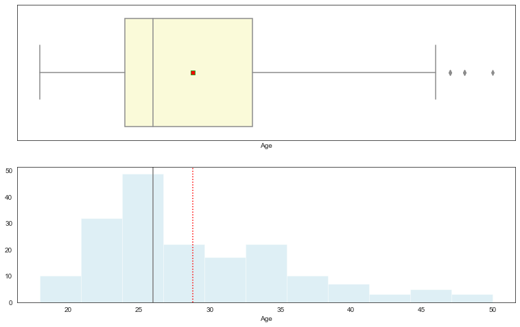

```python
hist_boxplot(cardio.Age)
```

**Observations**

- The distribution of Age is right skewed, showing that user are concentrate between 18 to 30 years old.
- Median (26) and mean (29) are nearby
- There are some outliers in this variable, customers around 45 to 50 years old.

## Observations on Education

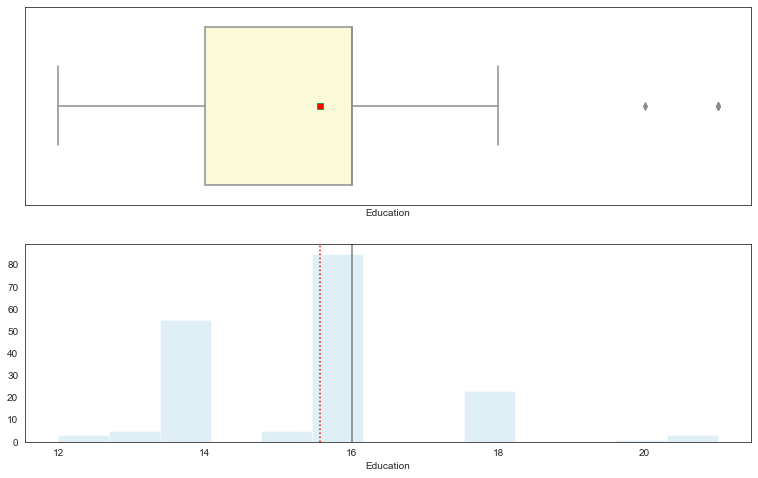

```python
hist_boxplot(cardio.Education)
```

**Observations**

- Education is concentrated around 16 year.
- Median and mean are almost the same, showing no skew.
- There are some outliers in this variable, showing 20 and 21 years of education.

## Observations on Usage

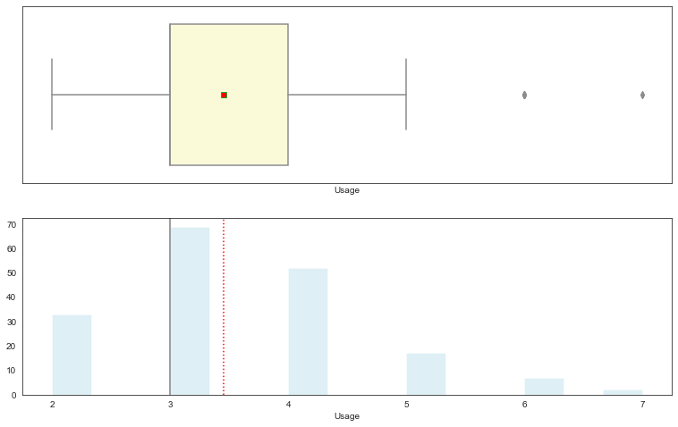

```python
hist_boxplot(cardio.Usage)
```

**Observations**

- Usage it is showing a positive skew, concentrated between 3 and 4 times per week;
- There are some outliers in this variable, showing 6 and 7 times/week using the treadmill.

## Observations on Fitness

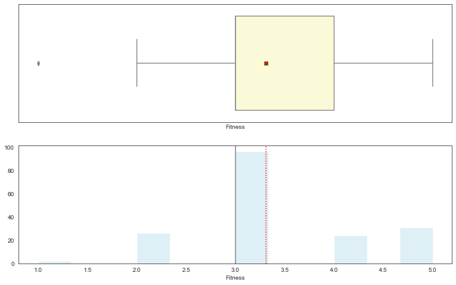

```python
hist_boxplot(cardio.Fitness)
```

**Observations**

- Self rate score is concentrated around 3, showing moderate Fitness.
- Median (3) and mean (3.3) are almost the same, showing no skewness.
- There are 2 customers that self rate themself as 1, and they are the outliers.

## Observations on Income

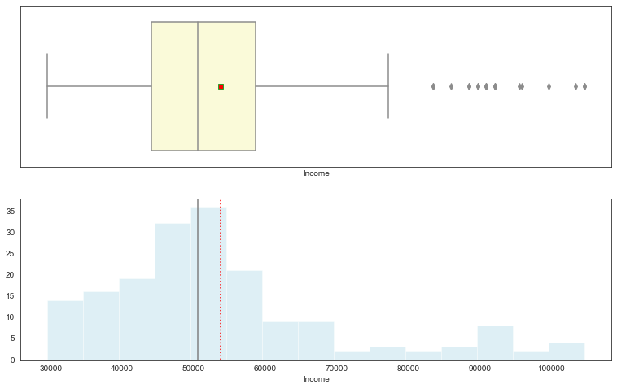

```python
hist_boxplot(cardio.Income)
```

**Observations**

- Income has a right skwness,showing a lot of outliers on the right side;
- The mean income of Customers is around $50k, but the maximum is around 105k.

## Observations on Miles

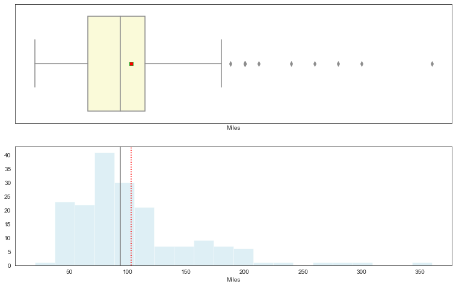

```python
hist_boxplot(cardio.Miles)
```

**Observations**

- There are some outliers on Miles equal to or greater than 200;
- Miles has a right skewness and mean around 100.

```python
# Filtering the data to see how many customers expecting to run more than 199 miles per week (outliers)
outliers_miles = cardio[cardio['Miles'] > 199]
outliers_miles['Miles'].value_counts().sum()
```

```
12
```

# *Uni-variate:* Exploring the categorical variables

```python
# Function to create barplots that indicate percentage for each category.

def bar_perc(dataframe, xlabel_df, colors, ylabel_df = 'Count'):
    """
    This function takes the category column as the input and returns the barplots with percentage values.
    dataframe: 1-d categorical feature array
    xlabel_df: x axis label
    ylabel_df: y axis label (default 'Count')
    colors: list of colors to use for the different variables
    """


    # Figure aesthetics
    sns.set_style("whitegrid")
    sns.set_context("talk")

    # Plot informations
    plt.figure(figsize=(12,6))
    plot_df = sns.countplot(dataframe, palette= colors)
    plt.xlabel(xlabel_df)
    plt.ylabel(ylabel_df)

    # Calculating the length of the column
    total = len(dataframe)

    # Looping to calculate percentage of each class of the category and annotate the percentage
    for cat in plot_df.patches:
        percentage = '{:.1f}%'.format(100 * cat.get_height()/total)

        #setting plot annotate location and size
        x = cat.get_x() + cat.get_width() / 2 - 0.05
        y = cat.get_y() + cat.get_height() + 1
        plot_df.annotate(percentage, (x, y), size = 14)
```

## Observations on Product

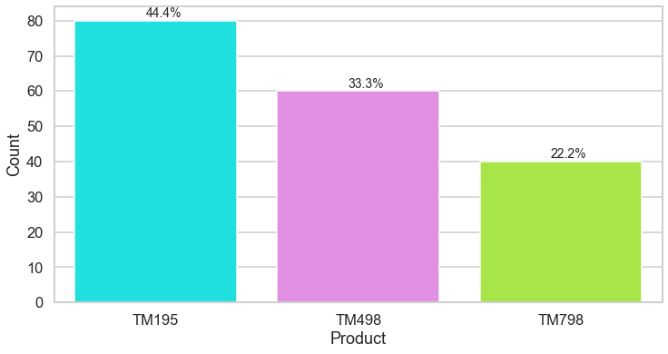

```python
# List of colors to use for the different products
colors = ['cyan', 'violet', 'greenyellow']

# Using the functio to plot barplot wtih percentage values
bar_perc(cardio['Product'],'Product',colors)
```

**Observations**

- The store has 3 models of TreadMill;
- TM195 is the most popular TreadMill, responsible for 44.4% of sales;
- TM498 is the second popular TreadMill and Tm798 the third.

## Observations on Gender

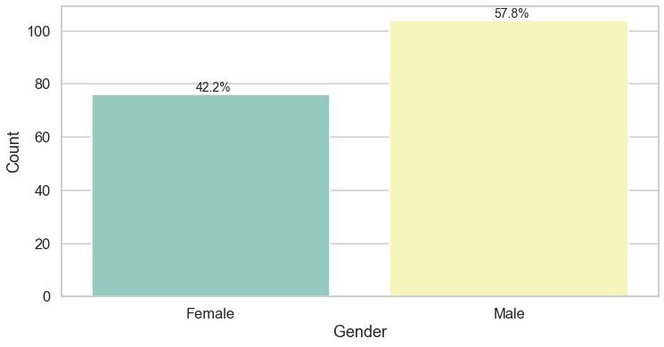

```python
# List of colors to use for the different gender
colors = "Set3"

# Using the functio to plot barplot wtih percentage values
bar_perc(cardio['Gender'],'Gender',colors)
```

**Observations**

- 57.8% of customers are Male, showing that Male are buying more than Female.

## Observations on Marital Status

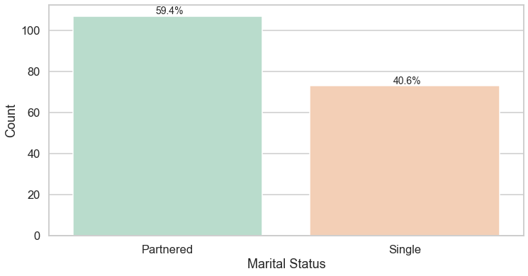

```python
# List of colors to use for the different Marital Status
colors = "Pastel2"

# Using the functio to plot barplot wtih percentage values
bar_perc(cardio['MaritalStatus'], 'Marital Status',colors)
```

**Observations**

- 59.4% of customers are Partnered.

# *Bivariate / Multivariate:* Understanding relationship between variables

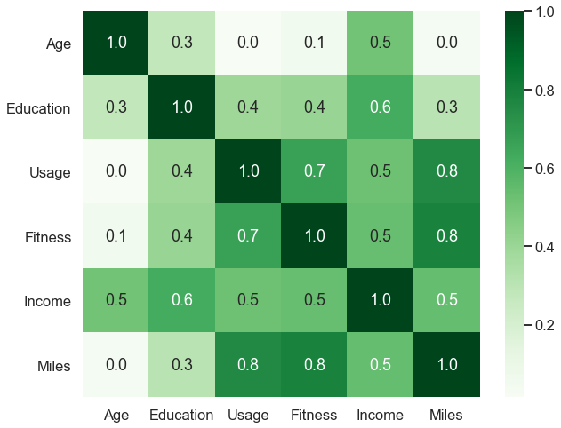

```python
# Understanding correlation among numerical variables
num_var = ['Age','Education','Usage','Fitness','Income', 'Miles']

corr = cardio[num_var].corr()

# Ploting the heatmap
plt.figure(figsize=(10,8))
sns.heatmap(corr, annot=True,cmap='Greens',fmt=".1f")
```

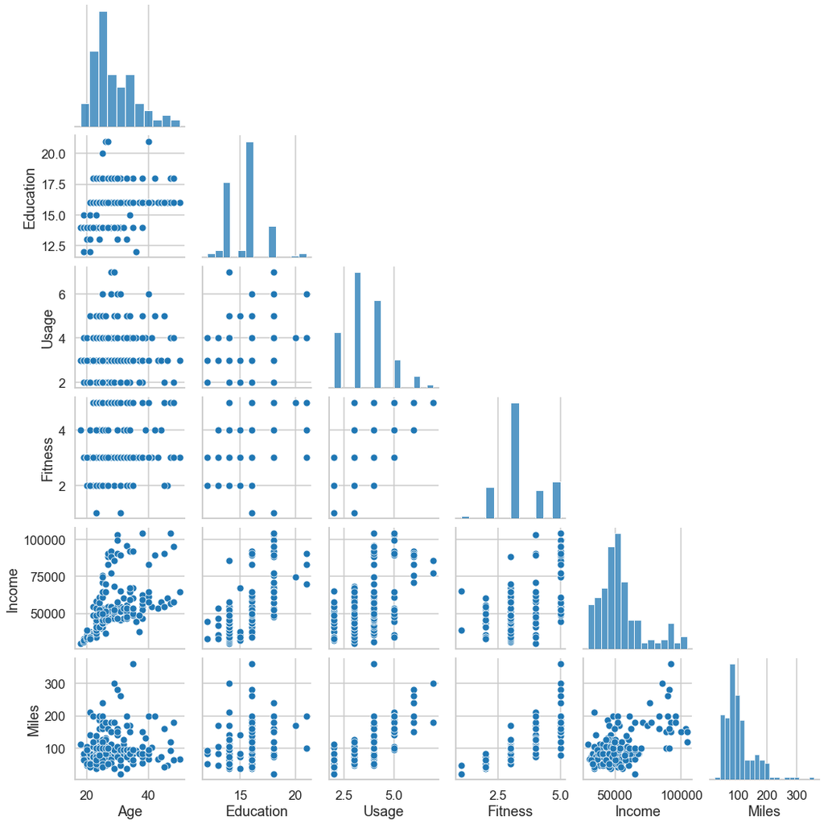

```python
# Ploting Bivariate Scatter Plots
sns.pairplot(cardio[num_var], corner=True)
```

**Observations**

- Age and Education is positive correlated with Income. This is an expected result;
- Fitness has a high positive correlation with Usage and Miles;
- It does not seem to be a strong relationship between Age and Fitness.

## Customer Profile

- **Product vs Income**

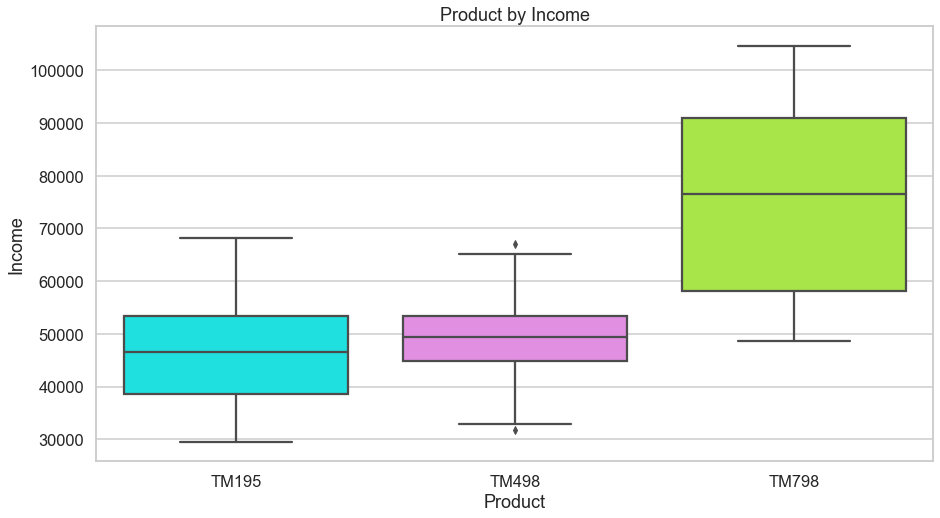

```python
# List of colors to use for the different products
colors = ['cyan', 'violet', 'greenyellow']

# Ploting boxplot for analysis about correlation between Product and Income
plt.figure(figsize=(15,8))

sns.boxplot(cardio['Product'],cardio['Income'], palette = colors)

#Setting Labels
plt.ylabel('Income')
plt.xlabel('Product')
plt.title('Product by Income')
```

**Observations**

- The store has 3 models of Treadmill;
- Customers with income greater than $70k tend to buy the product TM798;
- TM195 and TM498 have almost the same customer profile, with income less than 70k.
- **Income vs Age by product and usage**

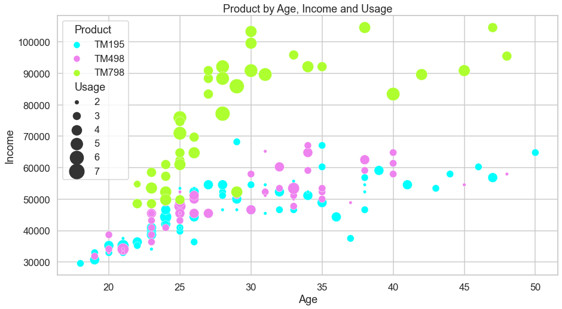

```python
# List of colors to use for the different product
colors = ['cyan', 'violet', 'greenyellow']

# Ploting scatterplot for analysis about correlation between Product, Age, Income and Usage
plt.figure(figsize=(15,8))

sns.scatterplot(cardio['Age'],cardio['Income'], hue =cardio['Product'],
                size = cardio['Usage'], sizes = (30, 600), palette = colors)

plt.title('Product by Age, Income and Usage')
```

**Observations**

- TM798 customers and expect to use 5 times per week (average);
- Age concentration for product TM798 and TM195 between 22 to 30 years old;
- TM195 and TM498 have almost the same customer profile, with fitness average of 3.
- **Age concentration**

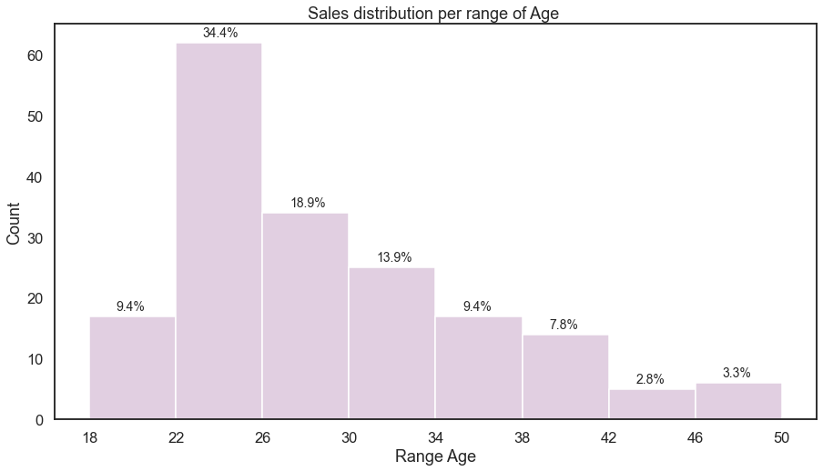

```python
#analyzing age distribution

sns.set_style("white")
plt.figure(figsize=(15,8))

# Plot informations
bins = np.linspace(18,50,9) #creating bins on evenly spaced number on range 18 to 50 (customers age)
plot_age = sns.histplot(data = cardio,x='Age',bins=bins, color='thistle')
plt.xlabel('Range Age')
plt.ylabel('Count')
plt.xticks([18, 22, 26, 30, 34, 38, 42, 46, 50]) #specifying ticks via the xticks function.
plt.title('Sales distribution per range of Age ')

# Calculating the length of the column
total = len(cardio['Age'])

# Looping to calculate percentage of bins and annotate the percentage
for age in plot_age.patches:
    percentage = '{:.1f}%'.format(100 * age.get_height()/total)
    x = age.get_x() + age.get_width() /2 -0.75
    y = age.get_y() + age.get_height() + 1
    plot_age.annotate(percentage, (x, y), size = 14)
```

**Observation**

- 67% of sales are concentrated on customer with range of age between 22 to 33 years old.
- **Age distribution by product**

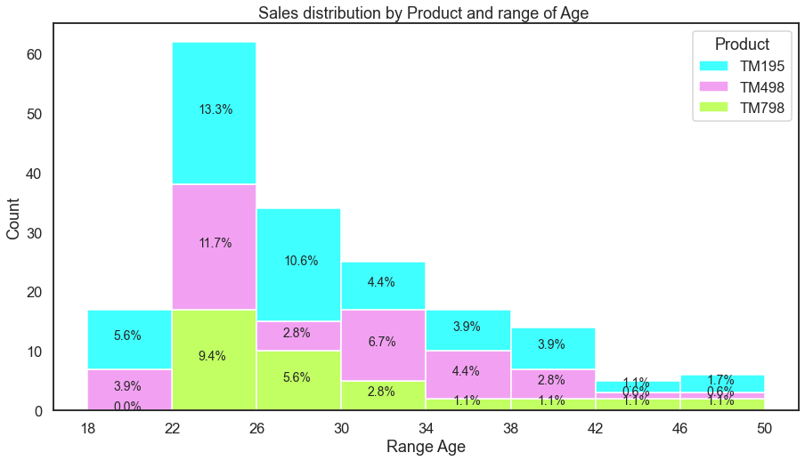

```python
#analyzing age distribution for product

sns.set_style("white")
plt.figure(figsize=(15,8))

# Plot informations
colors = ['cyan', 'violet', 'greenyellow']
bins = np.linspace(18,50,9) #creating bins on evenly spaced number on range 18 to 50 (customers age)

# Plotting stacked histogram
plot_age = sns.histplot(data = cardio,x='Age',bins=bins, hue="Product", multiple="stack",palette=colors)
plt.xlabel('Range Age')
plt.ylabel('Count')
plt.xticks([18, 22, 26, 30, 34, 38, 42, 46, 50]) #specifying ticks via the xticks function.
plt.title('Sales distribution by Product and range of Age ')

# Calculating the length of the column
total = len(cardio['Age'])

# Looping to calculate percentage of bins and annotate the percentage
for age in plot_age.patches:
    percentage = '{:.1f}%'.format(100 * age.get_height()/total)
    x = age.get_x() + age.get_width() /2 -0.75
    y = age.get_y() + age.get_height() /2
    plot_age.annotate(percentage, (x, y), size = 14)
```

**Observation**

- TM195 Range 18 to 29 years old represents 30% of total sales;
- TM498 Has a mixed range, 22 to 25 and 30 to 37, 23% of sales;
- TM798 Range 22 to 33 years old, 18% of total sales.
- **Income vs Fitness by product and usage**

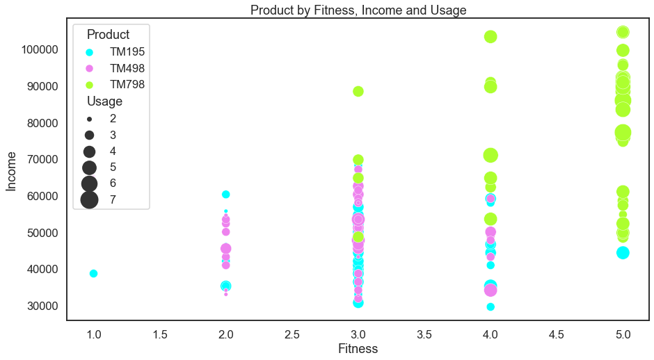

```python
# List of colors to use for the different product
colors = ['cyan', 'violet', 'greenyellow']

# Ploting scatterplot for analysis about correlation between Product, Age, Income and Usage
plt.figure(figsize=(15,8))

sns.scatterplot(cardio['Fitness'],cardio['Income'], hue =cardio['Product'],
                size = cardio['Usage'], sizes = (30, 600), palette = colors)

plt.title('Product by Fitness, Income and Usage')
```

**Observation**

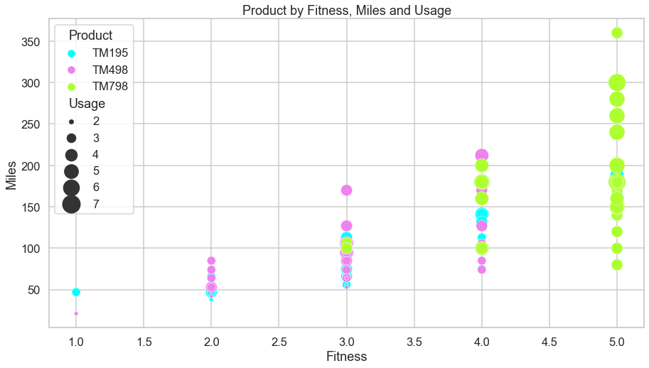

```python
# List of colors to use for the different product
colors = ['cyan', 'violet', 'greenyellow']

# Ploting scatterplot for analysis about correlation between Product, Fitness, Miles and Usage
sns.set_style("whitegrid")
plt.figure(figsize=(15,8))

sns.scatterplot(x='Fitness', y='Miles', data=cardio, hue=cardio['Product'],size = cardio['Usage'],
                sizes = (30, 600),palette = colors)

plt.title('Product by Fitness, Miles and Usage')
```

**Observation**

- Fitness and Miles has a hight strong correlation
- The product TM798 is used for people that is verry fit and expected to run more
- **Income vs Education by product**

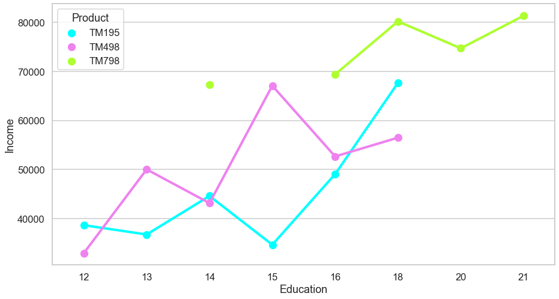

```python
# List of colors to use for the different product
colors = ['cyan', 'violet', 'greenyellow']

# Ploting scatterplot for analysis about correlation between Product, Age, Income and Usage
plt.figure(figsize=(15,8))

sns.pointplot(x='Education', y='Income', data=cardio, hue='Product', ci=None, palette = colors)
```

**Observation**

- Income and Education has some correlation
- Customer with more years of education tend to buy TM798.
- **Product vs Gender**

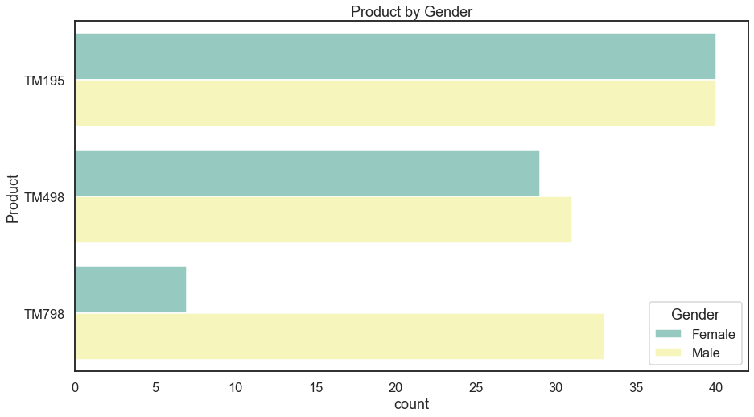

```python
# Ploting countplot for analysis between Product and Gender
sns.set_style("white")
plt.figure(figsize=(15,8))

sns.countplot(y=cardio['Product'], hue = cardio['Gender'], palette="Set3")

plt.title('Product by Gender')
```

- **Product vs Fitness by Gender**

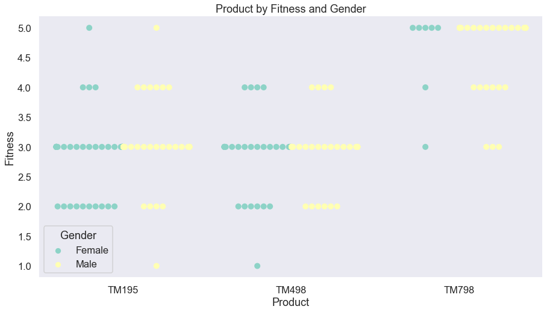

```python
# Ploting swarmplot for analysis between Product, Fitness and Gender
sns.set_style("dark")
plt.figure(figsize=(15,8))

sns.swarmplot(x='Product', y='Fitness', data=cardio, hue=cardio['Gender'], size=10, palette="Set3", dodge=True)

plt.title('Product by Fitness and Gender')
```

```python
gender_dist_TM498 = cardio[cardio['Product'] == "TM498"]
gender_dist_TM498['Gender'].value_counts()
```

```
Male      31
Female    29
Name: Gender, dtype: int64
```

```python
gender_dist_TM798 = cardio[cardio['Product'] == "TM798"]
gender_dist_TM798['Gender'].value_counts()
```

```
Male      33
Female     7
Name: Gender, dtype: int64
```

- **Product by Marital Status**

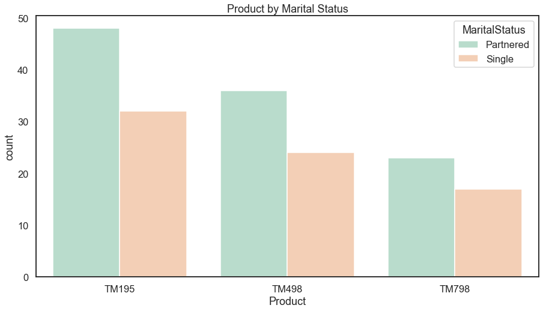

```python
# Ploting countplot for analysis between Product and Marital Status
sns.set_style("white")
plt.figure(figsize=(15,8))

sns.countplot(x=cardio['Product'], hue = cardio['MaritalStatus'], palette="Pastel2")

plt.title('Product by Marital Status')
```

**Observation**

- TM195 has equal number of Female and Male customers (40) and higher number of partnered.
- TM498 sales for male (31) is a little bit higher than for Female (29) and has higher number of partnered.
- TM798 sales for male (33) is considerably higher than for Female (7) , also preferable for partnered customers and the ones that self rate equal or greater than 3.